# 2010s Top Spotify Songs and What They Tell Us

Each decade is defined by unique musical styles, genre shifts, and the creation of new genres entirely. Many would say that music is a key part of a decade's identity and contributes to the cultural zeitgeist. When looking at the most popular songs from a specific decade, you would hope to learn something about that time period and why certain songs were popular. Global events, such as war, in addition to political movements and cultural shifts can substantially influence people's tastes during a certain time period. By analyzing top songs from Spotify during the 2010s, what you would hope to find out from the data would be a bit more interesting. Unlike the top songs from the radio or charts, top Spotify songs not only represent the kinds of songs you'd expect to find in those places, but often songs that are a bit more niche or even commercially unfriendly. As a service, Spotify allows users to access nearly any song in the world in exchange for viewing ads or paying a flat monthly fee. Due to the nature of the service, Spotify listeners feel perhaps more open to experimenting with unique music that they may not have listened to or known about otherwise. With this in mind, independent and experimental music has the opportunity to flourish. This kind of data is highly interesting, because it not only shows what is popular in the mainstream, but can reveal other tastes as well.

### Data Collection and Management

For this tutorial, I am using [this dataset](https://www.kaggle.com/datasets/muhmores/spotify-top-100-songs-of-20152019/discussion) that was already created based upon Spotify data from the years 2010-2019 as well as Spotify's Web API. It is important to thoroughly inspect your dataset to make sure that the data was collected properly and that it makes sense. While inspecting the data, I noticed that three completely empty rows were added onto the dataset erroneously, which I removed. Due to the nature of the dataset, I know that I should have 1000 entries, or 100 top songs per year of the decade. I then converted the year data from floats into integers, both due to aesthetic reasons and also because it is a bit easier to work with for these purposes, since a year will never be anything other than a whole number. Additionally, I noticed that a handful of release years were incorrect. For example, the song "Bohemian Rhapsody (Remastered 2011)" was incorrectly assigned the release year of 1975, which is when the original song came out, but not this remastered version included in the dataset. On the site where I got the dataset from, there were also official comments about this issue.

```python
import pandas as pd

song_data = pd.read_csv("Spotify 2010 - 2019 Top 100.csv")

# trim empty data
song_data = song_data[0:1000]

# convert floats to type int for better appearance and ease of use
song_data['year released'] = song_data['year released'].astype('Int64')
song_data['top year'] = song_data['top year'].astype('Int64')

# fix some clerical errors in the database
for i in range(len(song_data['title'])):
    if i == 69:
        song_data['year released'].iloc[i]=2010
    if i == 98:
        song_data['year released'].iloc[i]=2010
    if i == 651:
        song_data['year released'].iloc[i]=2016
    if i == 901:
        song_data['year released'].iloc[i]=2019
    if i == 951:
        song_data['year released'].iloc[i]=2019
    if i == 972:
        song_data['year released'].iloc[i]=2019
    if i == 168:
        song_data['year released'].iloc[i]=2011
    if i == 182:
        song_data['year released'].iloc[i]=2012
    if i == 608:
        song_data['year released'].iloc[i]=2019
    if i == 982:
        song_data['year released'].iloc[i]=2011

song_data
```

|  | title | artist | top genre | year released | added | bpm | nrgy | dnce | dB | live | val | dur | acous | spch | pop | top year | artist type |
| --- | --- | --- | --- | --- | --- | --- | --- | --- | --- | --- | --- | --- | --- | --- | --- | --- | --- |
| 0 | STARSTRUKK (feat. Katy Perry) | 3OH!3 | dance pop | 2009 | 2022‑02‑17 | 140.0 | 81.0 | 61.0 | -6.0 | 23.0 | 23.0 | 203.0 | 0.0 | 6.0 | 70.0 | 2010 | Duo |
| 1 | My First Kiss (feat. Ke$ha) | 3OH!3 | dance pop | 2010 | 2022‑02‑17 | 138.0 | 89.0 | 68.0 | -4.0 | 36.0 | 83.0 | 192.0 | 1.0 | 8.0 | 68.0 | 2010 | Duo |
| 2 | I Need A Dollar | Aloe Blacc | pop soul | 2010 | 2022‑02‑17 | 95.0 | 48.0 | 84.0 | -7.0 | 9.0 | 96.0 | 243.0 | 20.0 | 3.0 | 72.0 | 2010 | Solo |
| 3 | Airplanes (feat. Hayley Williams of Paramore) | B.o.B | atl hip hop | 2010 | 2022‑02‑17 | 93.0 | 87.0 | 66.0 | -4.0 | 4.0 | 38.0 | 180.0 | 11.0 | 12.0 | 80.0 | 2010 | Solo |
| 4 | Nothin' on You (feat. Bruno Mars) | B.o.B | atl hip hop | 2010 | 2022‑02‑17 | 104.0 | 85.0 | 69.0 | -6.0 | 9.0 | 74.0 | 268.0 | 39.0 | 5.0 | 79.0 | 2010 | Solo |
| ... | ... | ... | ... | ... | ... | ... | ... | ... | ... | ... | ... | ... | ... | ... | ... | ... | ... |
| 995 | SICKO MODE | Travis Scott | hip hop | 2018 | 2020‑06‑22 | 155.0 | 73.0 | 83.0 | -4.0 | 12.0 | 45.0 | 313.0 | 1.0 | 22.0 | 86.0 | 2019 | Solo |
| 996 | EARFQUAKE | Tyler, The Creator | hip hop | 2019 | 2020‑06‑22 | 80.0 | 50.0 | 55.0 | -9.0 | 80.0 | 41.0 | 190.0 | 23.0 | 7.0 | 85.0 | 2019 | Solo |
| 997 | Boasty (feat. Idris Elba) | Wiley | grime | 2019 | 2020‑06‑22 | 103.0 | 77.0 | 89.0 | -5.0 | 9.0 | 46.0 | 177.0 | 1.0 | 7.0 | 68.0 | 2019 | Solo |
| 998 | Strike a Pose (feat. Aitch) | Young T & Bugsey | afroswing | 2019 | 2020‑08‑20 | 138.0 | 58.0 | 53.0 | -6.0 | 10.0 | 59.0 | 214.0 | 1.0 | 10.0 | 67.0 | 2019 | Duo |
| 999 | The London (feat. J. Cole & Travis Scott) | Young Thug | atl hip hop | 2019 | 2020‑06‑22 | 98.0 | 59.0 | 80.0 | -7.0 | 13.0 | 18.0 | 200.0 | 2.0 | 15.0 | 75.0 | 2019 | Solo |

1000 rows × 17 columns

After tidying the dataset, I have a nice dataframe that I can use to analyze this data. First, it's important to understand what all of the data means. Many of the columns, such as title, artist, top genre, year released, etc. are self-explanatory, but others require looking into in order to understand what they mean. According to the [Spotify Web API](https://developer.spotify.com/documentation/web-api/reference/#/operations/get-track), Here is what each of the columns means:

- title = song title
- artist = artist associated with the song
- top genre = genre associated with the song
- year released = year the song was released
- added = date song was added to Spotify's Top Hits playlist
- bpm = beats per minute
- nrgy = energy, a measure from 0.0 to 1.0 to represent a perceptual measure of intensity and activity; typically energetic tracks feel fast, loud, and noisy
- dnce = danceability, how suitable a track is for dancing based on a combination of musical elements including tempo, rhythm stability, beat strength, and overall regularity; a value of 0.0 is least danceable and 1.0 is most danceable
- dB = the overall loudness of a song measured in decibels (dB)
- live = liveness, detects the presence of an audience in the recording; higher liveness values represent an increased probability that the track was performed live, with a value above 0.8 providing a strong likelihood that the track is live
- val = a measure from 0.0 to 1.0 describing the musical positiveness conveyed by a song; those with high valence sound more positive (e.g. happy, cheerful)
- dur = duration of the song in seconds
- acous = acoustic, a confidence measure from 0.0 to 1.0 of whether the track is acoustic with 1.0 being the highest
- spch = speechiness, detects the presence of spoken words in a track; more exclusively speech-like the recordings (e.g. talk show, audio book, poetry) are closer to 1.0
- pop = popularity of the song, a value between 0 and 100, with 100 being the most popular; the popularity is calculated by algorithm and is based, in the most part, on the total number of plays the track has had and how recent those plays are
- top year = year the song was a top hit
- artist type = describes if artist is a solo artist, a duo, a trio, or a band

### Exploratory Data Analysis

The first thing I wanted to explore with the data was when these top songs were being created. In recent years, it has not been uncommon to see songs from decades ago become popular again due to TikTok or some other trend. Additionally, I thought it was possible that people might be streaming some of their old favorite songs instead of newer ones. I created a dataframe to easily see how many of these top songs were from specific decades. According to that, the vast majority of top songs were from the 2010 decade, with only a couple dozen songs originating from the 2000s. It makes sense that people would want to listen to the newest songs, but it also enriches the dataset to know that the top songs were almost always a reflection on current trends and music tastes rather than past ones.

```python
count_dec = [0] * 7
decades = [1950, 1960, 1970, 1980, 1990, 2000, 2010]
curr_song = 0

# iterate through year released column in order to identify which top songs came from which decades
# start at 1950s because there are likely no songs from before then
for i in range(0, len(song_data['year released'])):
    if abs(song_data['year released'][i] - song_data['top year'][i]) < 3:
        curr_song += 1
    if song_data['year released'][i] >= 1950 and song_data['year released'][i] < 1960:
        count_dec[0] += 1
    elif song_data['year released'][i] >= 1960 and song_data['year released'][i] < 1970:
        count_dec[1] += 1
    elif song_data['year released'][i] >= 1970 and song_data['year released'][i] < 1980:
        count_dec[2] += 1
    elif song_data['year released'][i] >= 1980 and song_data['year released'][i] < 1990:
        count_dec[3] += 1
    elif song_data['year released'][i] >= 1990 and song_data['year released'][i] < 2000:
        count_dec[4] += 1
    elif song_data['year released'][i] >= 2000 and song_data['year released'][i] < 2010:
        count_dec[5] += 1
    elif song_data['year released'][i] >= 2010 and song_data['year released'][i] < 2020:
        count_dec[6] += 1

data = {'Decade':decades, 'Song Count':count_dec}
df = pd.DataFrame(data)
df
```

|  | Decade | Song Count |
| --- | --- | --- |
| 0 | 1950 | 0 |
| 1 | 1960 | 0 |
| 2 | 1970 | 0 |
| 3 | 1980 | 0 |
| 4 | 1990 | 0 |
| 5 | 2000 | 24 |
| 6 | 2010 | 976 |

I decided to also take a look at the origin years of the top songs, since I now know they are confined to only two decades. From here I can see that the only songs from the 2000s are from 2009, which makes sense as to how they could have become top songs, most likely in 2010. It isn't uncommon at all for a song to be released in a certain year, maybe late into the year, and then become a hit song after the new year comes along. Based on this information, we can probably assume that most of the songs became top songs within a few years of being released.

```python
song_data.groupby('year released')['year released'].count()
```

```
year released
2009     24
2010     96
2011     95
2012    110
2013     86
2014    101
2015     99
2016     87
2017     99
2018    112
2019     91
Name: year released, dtype: int64
```

Next, it may be interesting to examine which artists had the most top songs throughout the decade. Here we can see that Taylor Swift had the most top songs throughout the decade, followed by Calvin Harris, Drake (tie), Rihanna, and Ariana Grande (tie). To see these artists topping the list is not unexpected, but seeing Taylor Swift at the top of the list, an artist who is known to play around with genres, might be an interesting indication towards the musical trends of the decade.

```python
top_artists = pd.DataFrame()
top_artists['Number of Top Songs'] = song_data.groupby('artist')['artist'].count()
top_artists
top_artists.sort_values('Number of Top Songs',ascending=False).head()
```

| artist | Number of Top Songs |
| --- | --- |
| Taylor Swift | 21 |
| Calvin Harris | 18 |
| Drake | 18 |
| Rihanna | 14 |
| Ariana Grande | 14 |

Analyzing how genres change throughout the 2010s is a wonderful and logical next step. However, upon examining the data, you may notice that the genres listed are often highly specific. For example, instead of just "rap", a song may be listed as "melodic rap" or "cali rap". From here, I decided it was important to group these niche genres into larger genres for the sake of analysis. Using my own discretion and what I know about notable genres of the decade, I examined the data and created 11 large genre categories: Pop, Rap, Hip Hop, Country, Emo, Rock, Metal, Indie, EDM/Electronic, R&B, and Soul. Because there are so many smaller genres that cannot reasonably be put into their own genres, I created a 12th category called "Other" that will include everything else. After deciding upon the categories, I quickly realized that a very large number of these larger song genres overlapped. For example, "indie rock", "pop soul", and even "indie pop rap" appeared as genres. I had to come up with a way to decide which songs would go into which genre categories. I ultimately decided to rank my genre categories based upon how much I thought that they would sonically overtake other genres. I also deliberately put pop as far down the ranking as possible, because I knew that so many songs would already be considered pop even without genre-overlap, and I didn't want to lose a lot of genre variety by over-classifying many songs as pop. I created a new column for my dataframe to keep track of these genre categories.

```python
genre_cat = []
genres = ["Pop", "Rap", "Hip Hop", "Country", "Emo", "Rock", "Metal", "Indie", "EDM/Electro", "R&B", "Soul", "Other"]
count = [0] * 12

# loop through genre column and sort each song into one of 12 larger categories
for i in song_data['top genre']:
    if "rap" in i:
        genre_cat.append("rap")
        count[1] += 1
    elif "hip hop" in i:
        genre_cat.append("hip hop")
        count[2] += 1
    elif "country" in i:
        genre_cat.append("country")
        count[3] += 1
    elif "emo" in i:
        genre_cat.append("emo")
        count[4] += 1
    elif "rock" in i:
        genre_cat.append("rock")
        count[5] += 1
    elif "metal" in i:
        genre_cat.append("metal")
        count[6] += 1
    elif "indie" in i:
        genre_cat.append("indie")
        count[7] += 1
    elif "r&b" in i:
        genre_cat.append("r&b")
        count[9] += 1
    elif "soul" in i:
        genre_cat.append("soul")
        count[10] += 1
    elif ("edm" or "elect") in i:
        genre_cat.append("edm")
        count[8] += 1
    elif "pop" in i:
        genre_cat.append("pop")
        count[0] += 1
    else:
        genre_cat.append("other")
        count[11] += 1

song_data["genre category"] = genre_cat
```

After creating the genre categories, I plotted the decade totals for each. As suspected, the pop genre leads by a substantial amount, encompassing over half of all top songs throughout the decade. It was expected that pop would be the top genre here, since it's extremely popular and it makes sense that so many Spotify users would be listening to pop songs. Although they don't come close to pop's numbers, hip hop, rap, and other are the next few most common genres. However, other being included in this is mostly meaningless since it's just a collection of genres that were too difficult to fit into their own genre categories.

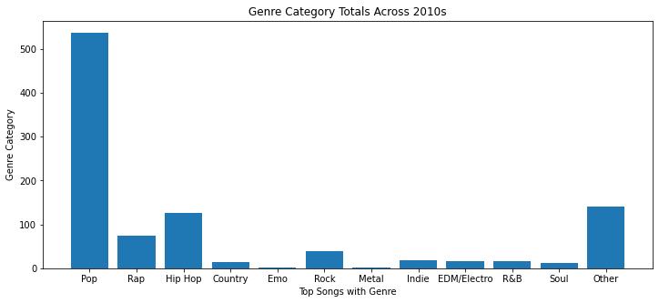

```python
fig = plt.figure(figsize = (12, 5))
plt.bar(genres, count, width=0.8)
plt.title("Genre Category Totals Across 2010s")
plt.xlabel("Top Songs with Genre")
plt.ylabel("Genre Category")
plt.show()
```

Now that we can see which genres were the most popular across the decade, it would be valuable to know how the popularities of these genres varied from year to year. Did some genres become more or less common for Spotify listeners throughout the decade? I decided to plot the occurences of each genre category for each year so that I could observe these changes. Based on the plot, we can see that pop consistently performs well from year-to-year with a slight drop-off starting in 2017. Most of the other genres do not seem to have much variation in their performance, except for other, hip hop, and rap. Again, because other is composed of many small genres, we are unable to draw many conclusions from here. Instead, we are more interested in rap and hip hoop, which have clearly become more common for Spotify listeners around the year 2017, the same year that pop began to decline.

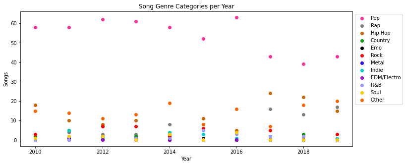

```python
# colors for each genre category
colors = {"Pop":"#FF3399", "Rap":"#808080", "Hip Hop":"#CC6600", "Country":"#009900", "Emo":"#000000", "Rock":"#FF0000", "Metal":"#3300FF",
          "Indie":"#00CCCC", "EDM/Electro":"#9900CC", "R&B":"#9999FF", "Soul":"#FFCC00", "Other":"#FF6600"}

fig = plt.figure(figsize = (12, 5))

# loop through genre category column and count the occurences of each genre, going through the genres list one-by-one
for g in genres:
    yrs = {2010.0: 0, 2011.0: 0, 2012.0: 0, 2013.0: 0, 2014.0: 0, 2015.0: 0, 2016.0: 0, 2017.0: 0, 2018.0: 0, 2019.0:0}
    for i in range(0, len(song_data['genre category'])):
        if song_data["genre category"][i] == g.lower():
            y = song_data["top year"][i]
            yrs[y] += 1
    plt.scatter(years, list(yrs.values()), color=colors[g])
plt.title("Song Genre Categories per Year")
plt.xlabel("Year")
plt.ylabel("Songs")
plt.legend(genres, bbox_to_anchor=(1,1))
plt.show()
```

In order to see the progression of each of the previously mentioned genres even more clearly, I put them onto their own plot and drew lines. From here, we can more clearly see that starting from the year 2015 or 2016, pop compared to rap or hip hop seems to have a clear relationship. As pop decreases, rap and hip hop generally increase. As pop increases, rap and hip hop generally decrease. This kind of relationship is even more precise between pop and hip hop, which almost seem to act as mirrors of each other from 2015 onwards. This raises obvious questions as to why Spotify users seem to listen to less pop in years where they are consuming more rap and hip hop, and vice versa.

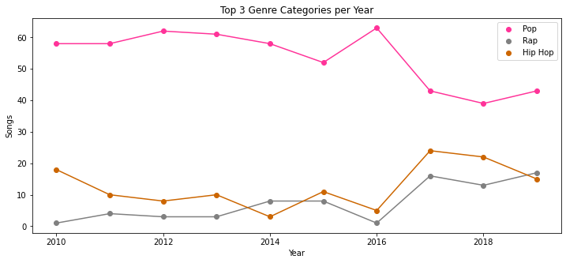

```python
fig = plt.figure(figsize = (12, 5))
top_colors = {"Pop":"#FF3399", "Rap":"#808080", "Hip Hop":"#CC6600"}
top_genres = ["Pop", "Rap", "Hip Hop"]

for gen in top_genres:
    yrs = {2010.0: 0, 2011.0: 0, 2012.0: 0, 2013.0: 0, 2014.0: 0, 2015.0: 0, 2016.0: 0, 2017.0: 0, 2018.0: 0, 2019.0:0}
    for i in range(0, len(song_data['genre category'])):
        if song_data["genre category"][i] == gen.lower():
            y = song_data["top year"][i]
            yrs[y] += 1
    plt.scatter(years, list(yrs.values()), color=top_colors[gen], label=gen)
    plt.plot(years, list(yrs.values()), color=top_colors[gen])
plt.title("Top 3 Genre Categories per Year")
plt.xlabel("Year")
plt.ylabel("Songs")
plt.legend()
plt.show()
```

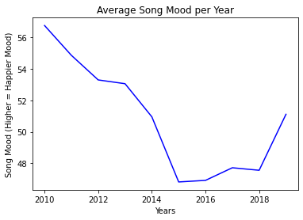

```python
import numpy as np

years = []
occ = [0] * 12
for i in range(2010, 2020):
    years.append(i)

# loop through each year to calculate the average song mood per year
a = []
for i in years:
    b = []
    for j in range(0, len(song_data['val'])):
        if song_data['top year'][j] == i:
            b.append(song_data["val"][j])
    a.append(np.mean(b))
plt.plot(years, a, color='blue')
plt.title("Average Song Mood per Year")
plt.xlabel("Years")
plt.ylabel("Song Mood (Higher = Happier Mood)")
plt.show()
```

Here I plotted the average song danceability and energy throughout the decade. Before plotting, I expected there to be a correlation between the two, believing that energetic songs would also be danceable. Apparently, that is not the case. It seems that as the decade has progressed, Spotify listeners have enjoyed more danceable music, which spikes at the same time when we could see the increasing popularity of hip hop and rap on a previous rap. Song energy, however, has consistantly decreased from the beginning of the decade. And of course, it is certainly possible for a song to be both danceable and low energy. One only has to look towards musical styles like trap and "mumble rap" in order to see this possibility.

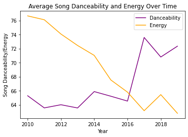

```python
# loop through each year to calculate both the average danceability and energy per year

a = []
b = []
for i in years:
    c = []
    d = []
    for j in range(0, len(song_data['val'])):
        if song_data['top year'][j] == i:
            d.append(song_data["dnce"][j])
            c.append(song_data["nrgy"][j])
    b.append(np.mean(d))
    a.append(np.mean(c))

plt.plot(years, b, color='purple', label="Danceability")
plt.plot(years, a, color='orange', label="Energy")
plt.title("Average Song Danceability and Energy Over Time")
plt.xlabel("Year")
plt.ylabel("Song Danceability/Energy")
plt.legend()
plt.show()
```

I also wanted to examine how average song length has changed throughout the decade, especially upon observing that songs have become more danceable. I would assume that shorter songs tend to be more danceable, since there are less lyrics and parts of the song for listeners to memorize, making it easier to dance to. Although the average song length has not decreased drastically from the beginning to the decade to the end, going from close to 4 minutes long to a little over 3 minutes long, there is a clear preference for shorter songs throughout the decade.

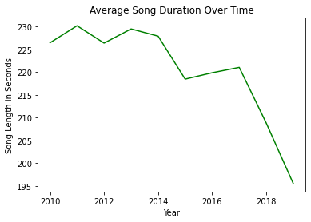

```python
# loop through each year to calculate the average song duration per year

a = []
for i in years:
    b = []
    for j in range(0, len(song_data['dur'])):
        if song_data['top year'][j] == i:
            b.append(song_data["dur"][j])
    a.append(np.mean(b))
plt.plot(years, a, color='green')
plt.title("Average Song Duration Over Time")
plt.xlabel("Year")
plt.ylabel("Song Length in Seconds")
plt.show()
```

### Hypothesis Testing

After exploring and thoroughly analyzing my data, I wanted to delve deeper into why Spotify listeners seemed to have an inverse relationship to preferring pop vs. rap/hip hop after 2016. The first thing I wanted to do was see if I could build a model that could accurately predict which songs are popular, which might explain this. Perhaps Spotify's strange preference for either pop or rap/hip hop is not related to genre at all, but something else entirely. In order to explore this, I created a predictive linear regression. I decided that based on previous graphs, danceability, energy, song length, and song mood were not ideal methods to predict which songs were popular. However, based on the overwhelming popularity of pop, hip hop, rap, and even rock throughout the decade, I decided that acousticness might be a decent predicter, since all of the most popular genres are not very acoustic. After plotting, I discovered that while acousticness was not an awful predicter and that it did actually generally follow the trend for what is popular, there were too many outliers for it to be a reliable method of predicting.

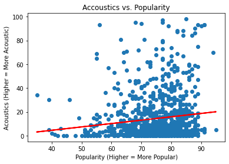

```python
from sklearn.linear_model import LinearRegression

# create linear regression
x = np.array(song_data["pop"]).reshape(-1, 1)
y = np.array(song_data["acous"]).reshape(-1, 1)

reg = LinearRegression().fit(x, y)

coef = reg.coef_
inter = reg.intercept_

# plot linear regression
plt.figure()
plt.scatter(x, y)
plt.plot(x, reg.predict(x), color = 'red', linewidth = 2)
plt.title("Accoustics vs. Popularity")
plt.xlabel("Popularity (Higher = More Popular)")
plt.ylabel("Acoustics (Higher = More Acoustic)")
plt.show()
```

I decided to move on to creating a decision tree in order to try to predict the popularity of top songs. I used bpm, energy, danceability, loudness, probability of live song, mood, duration, acousticness, and speechiness as test data. After building the decision tree, I found out that it was unable to come up with an accurate method of predicting. The accuracy was only 0.093. This leads me to believe that it is too difficult to predict the popularity of a top song, at least with this data. I assume this is because music tastes have varied too much throughout the decade, so it is hard to pin down exactly what quality makes a song popular. Especially because, as we've seen, many things that were present in top songs in the beginning of the decade were phased out by the end.

```
Accuracy of Decision Tree:  0.0930
```

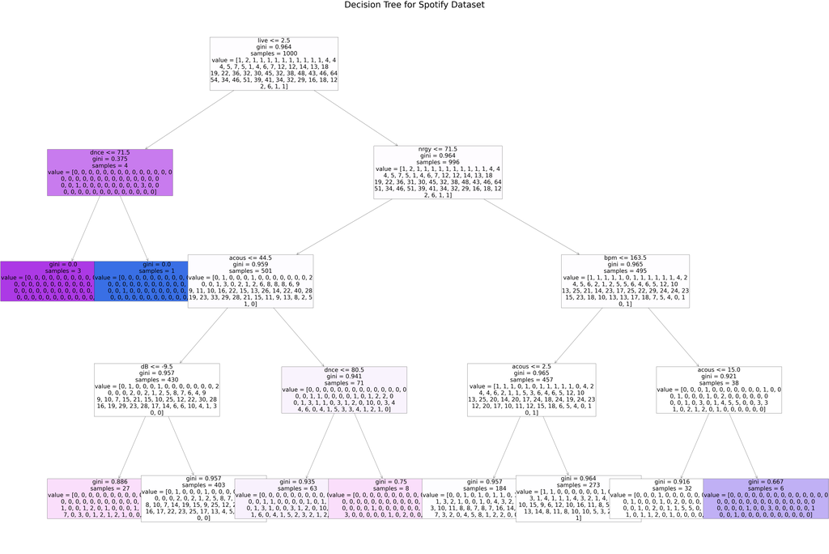

```python
 # Decision Tree
from sklearn.tree import DecisionTreeClassifier, plot_tree
from sklearn.metrics import accuracy_score

# traing and testing data
x_train = song_data[["bpm", "nrgy", "dnce", "dB", "live", "val", "dur", "acous", "spch"]]
x_test = song_data[["bpm", "nrgy", "dnce", "dB", "live", "val", "dur", "acous", "spch"]]
y_train = song_data['pop']
y_test = song_data['pop']

decision_tree = DecisionTreeClassifier(max_depth = 4)
features = ["bpm", "nrgy", "dnce", "dB", "live", "val", "dur", "acous", "spch"]
classes = ['pop', 'rap', 'hip hop', 'country', 'emo', 'rock', 'metal', 'indie', 'edm/electro', 'r&b', 'soul', 'other']

# test accuracy
decision_tree.fit(x_train,y_train)
prediction = decision_tree.predict(x_test)
print("Accuracy of Decision Tree: ", "{:.4f}".format(accuracy_score(prediction,y_test)))

# plot decision tree for visuals
plt.figure(figsize = (100, 70))
plot_tree(decision_tree, feature_names = features, filled = True, fontsize=40);
plt.title("Decision Tree for Spotify Dataset", fontsize=60)
plt.show()
```

For a different approach, I decided to see if using bpm, energy, danceability, loudness, probability of live song, mood, duration, acousticness, popularity, and speechiness as test data could accurately predict a top song's genre category. I considered that if what makes a song popular varies too much throughout a decade, a genre probably has stable enough criteria so that it could be accurately predicted. However, the accuracy of the decision tree still ended up only being 0.587, which is not a very satisfactory accuracy rate. This leads us to conclude that genre cannot be accurately predicted based upon the present data either. Thinking back on previous steps of this tutorial, we saw that before the genre categories that were used to create this decision tree were created, many genres had significant overlap. Addtionally, the graph that showed that hip hop and rap were increasing while pop was decreasing seems to be becayse of this overlap. Therefore, it is reasonable to assume that perhaps genres in this decade have simply not been distinct enough in order to accurately predict them. This idea is not new, as musical commentators have been claiming for years that genres are bleeding together, as discussed in the New Yorker article ['Genre Is Disappearing. What Comes Next?'](https://www.newyorker.com/magazine/2021/03/15/genre-is-disappearing-what-comes-next)

```
Accuracy of Decision Tree:  0.5870
```

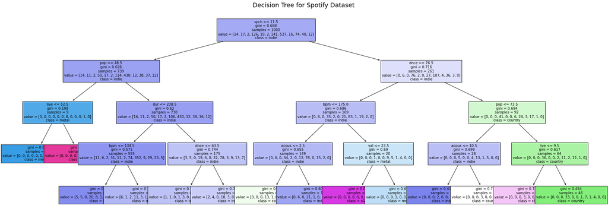

```python
# training and testing data
x_train = song_data[["bpm", "nrgy", "dnce", "dB", "live", "val", "dur", "acous", "spch", "pop"]]
x_test = song_data[["bpm", "nrgy", "dnce", "dB", "live", "val", "dur", "acous", "spch", "pop"]]
y_train = song_data['genre category']
y_test = song_data['genre category']

decision_tree = DecisionTreeClassifier(max_depth = 4)
features = ["bpm", "nrgy", "dnce", "dB", "live", "val", "dur", "acous", "spch", "pop"]
classes = ['pop', 'rap', 'hip hop', 'country', 'emo', 'rock', 'metal', 'indie', 'edm/electro', 'r&b', 'soul', 'other']

# test accuracy
decision_tree.fit(x_train,y_train)
prediction = decision_tree.predict(x_test)
print("Accuracy of Decision Tree: ", "{:.4f}".format(accuracy_score(prediction,y_test)))
plt.figure(figsize = (30, 11))

# plot decision tree
plot_tree(decision_tree, feature_names = features, class_names = classes, filled = True, fontsize=10);
plt.title("Decision Tree for Spotify Dataset", fontsize=18)
plt.show()
```

As a final test, I wanted to recreate the last decision tree using the original genre data instead of the category data I created in case this was causing issues. It turns out that my categorized genres had a higher rate of accuracy, as this decision tree's accuracy is only 0.390.

```python
# training and testing data
x_train = song_data[["bpm", "nrgy", "dnce", "dB", "live", "val", "dur", "acous", "spch", "pop"]]
x_test = song_data[["bpm", "nrgy", "dnce", "dB", "live", "val", "dur", "acous", "spch", "pop"]]
y_train = song_data['top genre']
y_test = song_data['top genre']

decision_tree = DecisionTreeClassifier(max_depth = 4)
features = ["bpm", "nrgy", "dnce", "dB", "live", "val", "dur", "acous", "spch", "pop"]

# test accuracy, no need to plot decision tree
decision_tree.fit(x_train,y_train)
prediction = decision_tree.predict(x_test)
print("Accuracy of Decision Tree: ", "{:.4f}".format(accuracy_score(prediction,y_test)))
```

```
Accuracy of Decision Tree:  0.3900
```

### Conclusion:

It is important to look back and examine musical trends of a decade, as they can tell us valuable information about that time period. Upon examining this Spotify Top Songs dataset from the 2010s, key trends were discovered. Songs became shorter, songs became less energetic, pop reigned strong, hip hop and rap gained more traction by the end of the decade, songs became a bit sadder, songs became more danceable. However, the most important take-away from evaluating music trends from this decade is the way in which once-distinct genres have seemed to melt together, making it difficult to categorize them. Because they are difficult to categorize, this also makes them difficult to recognize and predict. When hip hop and pop songs sound so similar, what truly differentiates them aside from perhaps perceptions about the artists who create those songs and a few other insignificant factors? As we progress through the decade following the 2010s, it will be interesting to see whether these genre-melding trends hold up, genres settle into themselves, or perhaps new genres entirely are created.